# STAT303_Mid-Term_Htet_Khant_Linn

Htet Khant Linn

STAT303 - Mid-Term

March 12, 2026

Install the necessary Library

```python
import numpy as np
import pandas as pd
import matplotlib.pyplot as plt
import statsmodels.api as sm
from statsmodels.tsa.arima_process import arma_generate_sample
from PythonTsa.plot_acf_pacf import acf_pacf_fig
from statsmodels.tsa.arima.model import ARIMA
from PythonTsa.LjungBoxtest import plot_LB_pvalue
from scipy import stats
```

## 1) Select the column from the dataset.

Load Data and Select Column H

```python
dataset = pd.read_csv("data/arma_dataset_mid_term.csv", index_col = 0, parse_dates = True)
print(dataset.info())
```

```
<class 'pandas.DataFrame'>
DatetimeIndex: 365 entries, 2026-01-01 to 2026-12-31
Data columns (total 15 columns):
 #   Column  Non-Null Count  Dtype
---  ------  --------------  -----
 0   1       365 non-null    float64
 1   2       365 non-null    float64
 2   3       365 non-null    float64
 3   4       365 non-null    float64
 4   5       365 non-null    float64
 5   6       365 non-null    float64
 6   7       365 non-null    float64
 7   8       365 non-null    float64
 8   9       365 non-null    float64
 9   10      365 non-null    float64
 10  11      365 non-null    float64
 11  12      365 non-null    float64
 12  13      365 non-null    float64
 13  14      365 non-null    float64
 14  15      365 non-null    float64
dtypes: float64(15)
memory usage: 45.6 KB
None
```

```python
print(dataset.head())
```

```
                   1         2         3         4         5         6  \
2026-01-01  0.496714 -0.480648  0.534629  0.195845 -0.579124 -0.285094
2026-01-02  0.159764  1.530021 -2.154582 -0.860866 -1.002045 -0.460053
2026-01-03  0.743547  3.966219 -2.128214 -0.108267  0.292374 -1.581832
2026-01-04  1.969158  4.003751 -0.734936 -1.767544  0.303742 -3.666223
2026-01-05  0.947341  3.189970  0.687931 -0.031371 -0.370243 -5.253175

                   7         8         9        10        11        12  \
2026-01-01 -0.138456  1.503420  0.441941 -0.718832 -0.401220 -0.080717
2026-01-02 -1.348909  1.022958 -0.692652  0.098056 -0.016640  0.030205
2026-01-03 -1.373197 -0.583946  0.628447  0.511749  0.002609 -1.980078
2026-01-04 -1.620728 -1.245237  0.780008 -0.064610  0.099241 -0.271719
2026-01-05 -1.731096 -0.944234  0.369418 -0.080813 -0.713465  0.183457

                  13        14        15
2026-01-01 -1.598124  0.408053  0.157128
2026-01-02 -0.976139  0.918045  0.506158
2026-01-03  1.721109  0.920089  0.136823
2026-01-04  0.307104 -0.573273 -0.220286
2026-01-05 -0.202011 -0.832516 -0.943065
```

```python
y = dataset['7']
print('--- My Dataset Head ---')
print(y.head())
print()

print('--- My Dataset Length ---')
print(len(y))
```

```
--- My Dataset Head ---
2026-01-01   -0.138456
2026-01-02   -1.348909
2026-01-03   -1.373197
2026-01-04   -1.620728
2026-01-05   -1.731096
Name: 7, dtype: float64

--- My Dataset Length ---
365
```

## 2) Plot the figure and name the y-axis as y and the x-axis as time, and the title is Time Series Plot.

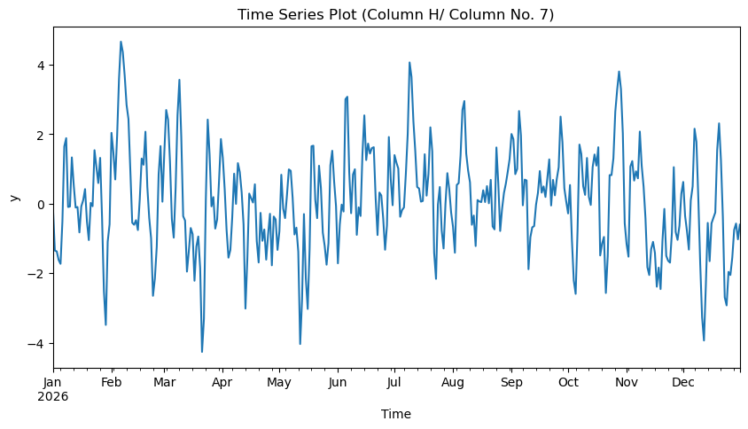

```python
y.plot(figsize=(10,5))
plt.title("Time Series Plot (Column H/ Column No. 7)")
plt.xlabel('Time')
plt.ylabel('y')

plt.savefig('output/time_series_plot')
plt.show()
```

## 3) If the time series has a trend, you need to use diff( ) to make it stationary; if not, you can skip to step 4.

## 5) Test the stationarity using the KPSS

### Test for Stationarity Using KPSS

The output of the KPSS test contains 4 things:

- The KPSS statistic
- p-value
- Number of lags used by the test
- Critical values

Source - [Click Here](https://machinelearningplus.com/time-series/kpss-test-for-stationarity/#:~:text=The%20output%20of%20the%20KPSS,lags%20used%20by%20the%20test)

```python
result = sm.tsa.stattools.kpss(y, regression='c', nlags=20)
print(f"KPSS Statistic: {result[0]}")
print(f"p-value: {result[1]}")
print(f"Lags: {result[2]}")
print(f"Critical Values: {result[3]}")
```

```
KPSS Statistic: 0.15808021366600225
p-value: 0.1
Lags: 20
Critical Values: {'10%': 0.347, '5%': 0.463, '2.5%': 0.574, '1%': 0.739}
```

Since the p-value is greater than 0.05, we can assume the data is **stationary** and proceed with d=0.

## 4) Plot the ACF and PACF using this time series.

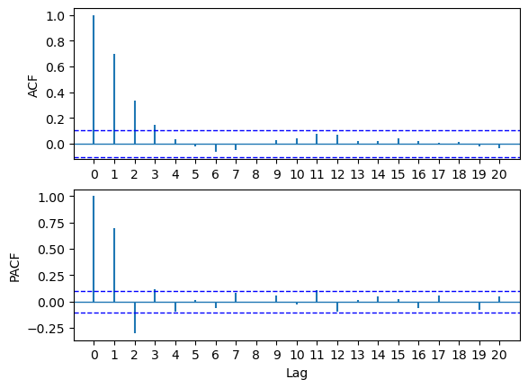

```python
acf_pacf_fig(y, both=True, lag=20)

plt.savefig('output/acf_pacf.png')

plt.show()
```

## 6) Choose the order of AR and MA

```python
inf = sm.tsa.arma_order_select_ic(y, max_ar=4, max_ma=4, ic=['aic', 'bic', 'hqic'], trend='c')
```

```python
print("Best AIC order:", inf.aic_min_order)  # Shows best model by AIC
```

```
Best AIC order: (np.int64(3), np.int64(1))
```

```python
print("Best BIC order:", inf.bic_min_order)  # Shows best model by BIC
```

```
Best BIC order: (np.int64(1), np.int64(1))
```

```python
print("Best HQIC order:", inf.hqic_min_order) # Shows best model by HQIC
```

```
Best HQIC order: (np.int64(1), np.int64(1))
```

## 7) Run the ARIMA model using the order that you choose.

```python
arima11 = ARIMA(y, order=(1,0,1), trend='c').fit()
print(arima11.summary())
```

```
                               SARIMAX Results
==============================================================================
Dep. Variable:                      7   No. Observations:                  365
Model:                 ARIMA(1, 0, 1)   Log Likelihood                -516.037
Date:                Thu, 12 Mar 2026   AIC                           1040.073
Time:                        21:53:09   BIC                           1055.673
Sample:                    01-01-2026   HQIC                          1046.273
                         - 12-31-2026
Covariance Type:                  opg
==============================================================================
                 coef    std err          z      P>|z|      [0.025      0.975]
------------------------------------------------------------------------------
const          0.1010      0.147      0.687      0.492      -0.187       0.389
ar.L1          0.4690      0.063      7.472      0.000       0.346       0.592
ma.L1          0.4980      0.064      7.751      0.000       0.372       0.624
sigma2         0.9872      0.074     13.373      0.000       0.843       1.132
===================================================================================
Ljung-Box (L1) (Q):                   0.01   Jarque-Bera (JB):                 0.01
Prob(Q):                              0.94   Prob(JB):                         1.00
Heteroskedasticity (H):               0.92   Skew:                            -0.00
Prob(H) (two-sided):                  0.65   Kurtosis:                         3.02
===================================================================================

Warnings:
[1] Covariance matrix calculated using the outer product of gradients (complex-step).
```

## 8) Test with normaltest( ) using the residuals.

Reference - [normaltest](https://docs.scipy.org/doc/scipy/reference/generated/scipy.stats.normaltest.html)

```python
resid11 = arima11.resid

norm_test = stats.normaltest(resid11)
print(f"Normality test statistic: {norm_test[0]}")
print(f"p-value: {norm_test[1]}")
```

```
Normality test statistic: 0.06446943472258876
p-value: 0.9682792834463669
```

This function (normaltest()) tests the null hypothesis that a sample comes from a normal distribution. The p-value is 0.9683, which is much greater than 0.05. p-value > 0.05 means we FAIL to reject the null hypothesis. The data comes from a normal distribution, showing that my residuals are normally distributed. This shows that my model is good.

## 9) Plot the ACF and PACF again using the residuals.

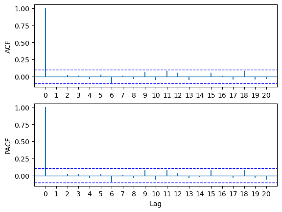

```python
acf_pacf_fig(resid11, both=True, lag=20)

plt.savefig("output/residuals_acf_pacf.png")
```

## 10) Plot the Ljung-Box statistic plot using the residuals.

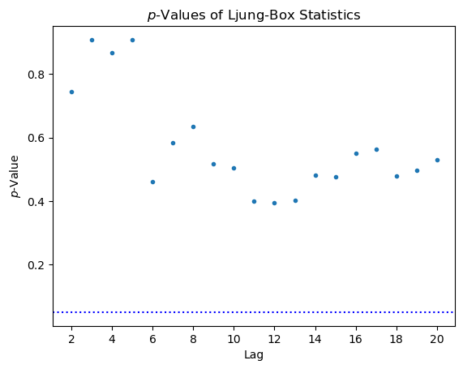

```python
plot_LB_pvalue(resid11, noestimatedcoef=1, nolags=20)

plt.savefig("output/residuals_ljung-box.png")

plt.show()
```

## 11) Make the prediction with 9 additional points.

## 12) Plot the prediction and the y values.

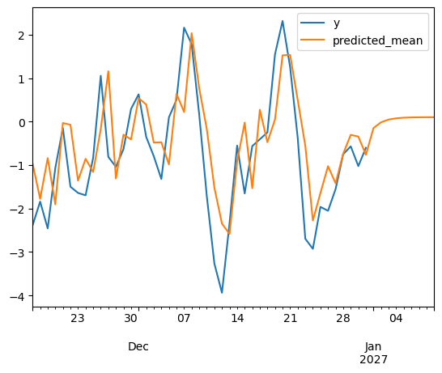

```python
pred = arima11.get_prediction(start=320, end=373)  # data has 365 points with indices from 0 to 364, so end at 364+9 = 373
predicts = pred.predicted_mean

predframe = pd.concat([y[320:], predicts], axis = 1)
predframe.columns = ['y', 'predicted_mean']

predframe.plot()

plt.savefig('output/prediction.png')
plt.show()
```

## 13) Write the equation from the summary of the ARIMA model.

$y_t = 0.1010 + 0.4690 y_{t-1} + \epsilon_t + 0.4980 \epsilon_{t-1}$